# Code_Example_Bar_Chart_Single_t-test

Kristina Sattler

2024-11-17

[Options for HTML appearance settings](https://docs.google.com/document/d/12yir4iAo4Y_E7MXwwrNkXOmGA0i5PhgYC6ubD6SwfOs/edit?usp=sharing)  
**Chunk 0 - Install or update packages (if needed- this only needs to be done once after downloading RStudio)**

```r
install.packages(c("tidyverse",
                   "readxl",
                   "dplyr",
                   "ggplot2",
                   "ggpubr",
                   "rstatix",
                   ))
```

**Chunk 1 - Load packages and set working directory**  
Set your working directory:  
> Session > Set Working Directory > Choose Directory > Choose directory containing the data file  
> Paste pathway in the knitr string (““) in line 36

```r
library(tidyverse)
library(readxl)
library(dplyr)
library(ggplot2)
library(ggpubr)
library(rstatix)
options(scipen = 999)  # converts all numbers to standard notation
knitr::opts_knit$set(root.dir = "~/Desktop/R_Files/Completed_Code")  # Set working directory
getwd()                                                 # Print working directory
```

```
## [1] "/Users/kristiesattler/Desktop/R_Files/Completed_Code"
```

**Chunk 2 - Open data file, set conditions, and set condition order**  
Replace components with values pertaining to your data > control + F  
- Condition_Column_Name [x19]  
- Data_Column_Name [x7]  
- Exp_Group1 [x6]  
- Exp_Group2 [x6]  
- Exp_Group1_color [x2] (color name, #hex_code, or RGB code)  
- Exp_Group2_color [x2]

```r
# Open data file with read excel
A_raw_data <- read_excel(                               # Open data file and create an object
  "CodeA_Example_Data_t-test_aligned_bar_chart.xlsx",   # Specify data file name
    #sheet = "Sheet_Name_If_Applicable",                 # Specify sheet (if applicable)
    #range = "First_cell:Last_Cell"                      # Specify the range (if applicable)
)
A_raw_data$Genotype <- as.factor(                       # Set condition column name as a factor
  A_raw_data$Genotype)                                  # Specify object and column
A_raw_data$Genotype <- factor(                          # Set the levels (order) of the experimental groups
  A_raw_data$Genotype,                                  # Specify data frame and column
  levels = c("Control",                                 # List groups in order
             "GNEmut"
             ))
```

**Chunk 3 - Create simple summary statistics**

```r
B_summary <- A_raw_data %>%    # Create a new data frame called B_summary
  group_by(Genotype) %>%       # Set data groups
  summarise(                   # Summarize these parameters for each group
    Mean = mean(SC),           #   Calculate the mean value
    n = n(),                   #   Calculate the number of samples
    SD = sd(SC),               #   Calculate the standard deviation
    SE = SD / sqrt(n),         #   Calculate the standard error
    Min = min(SC),             #   Calculate the minimum value of each group
    Max = max(SC)              #   Calculate the maximum value of each group
  )
B_summary$Genotype <- factor(  # Set the levels (order) of the experimental groups
  B_summary$Genotype,          #   Specify data frame and column
  levels = c("Control",        #   List groups in order (same as in Chunk 2)
             "GNEmut"
             ))
```

**Chunk 4 - Run t-test and collate results to a data frame**

```r
C_test_result <- t.test(                           # Run a t-test
  SC ~ Genotype,                                   #   Compare data grouped by the condition column
  data = A_raw_data,                               #   Specify data origin
  var.equal = TRUE)                                #   Assume equal variances
C_test_result_df <- data.frame(                    # Write results to a data frame
  group1 = levels(A_raw_data$Genotype)[1],         #   Call first level (Control) to propagate value
  group2 = levels(A_raw_data$Genotype)[2],         #   Call second level (Control) to propagate value
  t_statistic = C_test_result$statistic,           #   T-statistic
  p_value = C_test_result$p.value,                 #   p-value
  mean_difference = diff(C_test_result$estimate),  #   Difference between group means
  conf_low = C_test_result$conf.int[1],            #   Lower bound of confidence interval
  conf_high = C_test_result$conf.int[2],           #   Upper bound of confidence interval
  df = C_test_result$parameter                     #   Degrees of freedom
)
```

**Chunk 5 - Set significance labels, set graph appearances, and create the graph**  
Set these parameters:  
- y.position [line 130]  
- y_limit [line 131]  
- geom_errorbar > width [line 169]  
- labs > title [line 174]  
- labs > y [line 176]  
To remove dot data points, add a # at the beginning of lines 159-162: geom_point(…)  
[Options for Theme and geom_point appearance settings](https://docs.google.com/document/d/12yir4iAo4Y_E7MXwwrNkXOmGA0i5PhgYC6ubD6SwfOs/edit?usp=sharing)

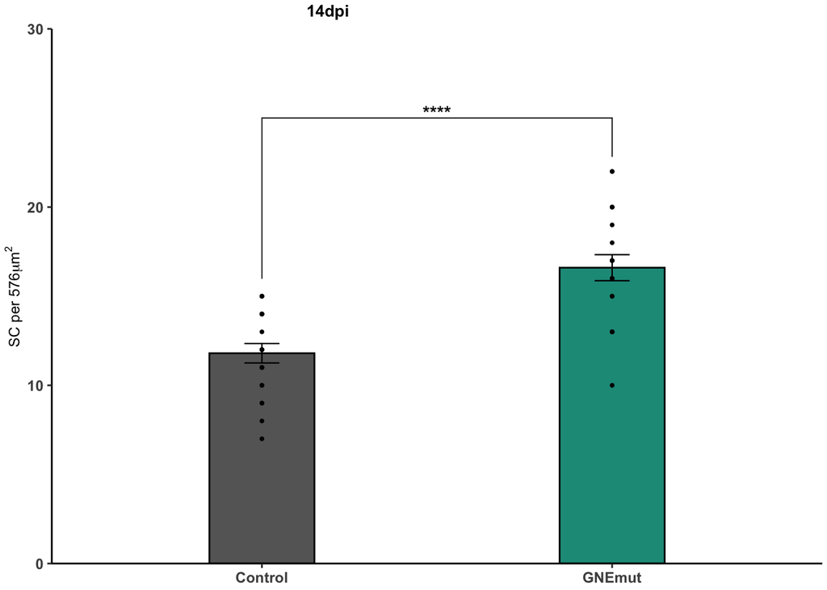

```r
C_test_result_df <- C_test_result_df %>%              # Add elements to the test result data frame
  mutate(                                             #  Create new columns
    label = case_when(                                #   Set the label under these Condition_Column_Names
      `p_value` <= 0.0001 ~ "****",                   #     If the p-value is < 0.001, label with ****
      `p_value` <= 0.001 ~ "***",                     #     If the p-value is < 0.01, label with ***
      `p_value` <= 0.01 ~ "**",                       #     If the p-value is < 0.01, label with **
      `p_value` <= 0.05 ~ "*",                        #     If the p-value is < 0.05, label with *
      TRUE ~ "ns"                                     #     If the p-value is > 0.05, label with ns
      ),
    p_label = ifelse(                                 #  Create a new column with conditional requirements
      p_value >= 0.05,                                #   Specify the p-value cutoff for nto significant
      paste0("ns, p=",                                #   If p is not significant, paste the p-value along with ns
             format(p_value, digits = 3)),            #     Format the label as p-value pasted to three digits
      label                                           #   Use the label column for significant p-values
      ),
    y.position = c(25),                               #  Set the y position of the comparison bars/labels
    y_limit = 30,                                     #  Record the value of the y-axis length
    )

B_summary <- B_summary %>%                            # Add elements to the summary data frame
  mutate(                                             #  Create new columns
    tip_length = c(0.5, 0.12),                        #   Specify left and right tip length values
    Colors = c("Control" = "#666666ff",               #   Specify color of Control
               "GNEmut" = "#1a9988ff"                 #   Specify color of GNEmut
    ))
V_colors <- setNames(B_summary$Colors,                # Create a dynamic object from the color column to assign to the plot
                      B_summary$Genotype)

S_bar_dot_plot <- ggdotplot(                          # Create the aligned dot plot with bars using ggdotplot
  A_raw_data,                                         #  Call the original data file
  x = "Genotype",                                     #  Set the x-axis to the Condition_Column_Name column
  y = "SC",                                           #  Set the y-axis to the data column
  dotsize = 0,                                        #  Sets the size of the data dots from ggdotplot to 0
  binwidth = 1                                        #  Control the spacing between bars
  ) +
  geom_col(                                           # Add bars displaying the average of each group
    data = B_summary,                                 #   Call data from the summary table
    aes(x = Genotype,                                 #   Set the aesthetic characteristics and call the column
        y = Mean,                                     #    Set the Y value of each bar to the mean of each group
        fill = Genotype),                             #    Fill the bars with data from each Condition
    color = "black",                                  #   Outline the bars in black
    width = 0.3,                                      #   Set the width of the bars
    alpha = 1,                                        #   Set opacity of the bars
  ) +
  geom_point(                                         # Set data point appearances
    shape = 16,                                       # Set data point type (see line 112 for options)
    size = 1,                                         #   Set the size of the data points
  ) +
  geom_errorbar(                                      # Create error bars
    data = B_summary,                                 #   Call data from B_summary
    aes(x = Genotype,                                 #   Fill data from the Condition_Column_Name column
        ymin = Mean - SE,                             #    Set the minimum y value of the error bar
        ymax = Mean + SE),                            #    Set the maximum y value of the error bar
    color = "black",                                  #   Set the colors for error bars
    width = 0.1,                                      #   Set the width of the error bar ends
    linewidth = 0.4,                                  #   Set the thickness of the line
    inherit.aes = FALSE                               #   Do not inherit aesthetic characteristics from ggdotplot
  ) +
  labs(                                               # Set labels
    title = "14dpi",                                  #  Set the title of the graph
    x = NULL,                                         #  Set the title of the x-axis [NULL if no title]
    y = expression("SC per 576" * mu * "m"^2 * ""),   #  Set the title of the y-axis
    fill = NULL                                       #  Remove ggdotplot shapes from the legend
  ) +
  scale_fill_manual(values = V_colors) +              # Call colors column to set sample colors
  theme_classic() +                                   # Set the appearance of the chart (See line 112 for options)
  theme(                                              # Set appearance of specific components of the chart
    plot.title = element_text(                        #  Set visual parameters of the chart title
      face = "bold",                                  #   Set chart title text to bold
      hjust = 0.35,                                   #   Set horizontal justification of the title
      size = 10,                                      #   Set chart title text size to 10
      ),
    axis.text.y = element_text(                       #  Set visual parameters of the y-axis
      face = "bold",                                  #   Set y-axis text to bold
      size = 9,                                       #   Set y-axis text size to 9
      ),
    axis.text.x = element_text(                       #  Set visual parameters of the x-axis
      face = "bold",                                  #   Set x-axis text to bold
      #hjust = 1,                                      #   Set horizontal justification of the bar labels
      size = 9,                                       #   Set x-axis text size to 9
      #angle = 45,                                     #   Set x-axis bar labels to 45^o angle
      ),
    axis.title.y = element_text(                      #  Set visual parameters of the y-axis title
      face = "bold",                                  #   Set y-axis title text to bold
      size = 9,                                       #   Set y-axis title text size to 9
      margin = margin(r = 1),                         #   Set the distance of the y-axis title to the axis
      ),
    plot.margin = unit(c(0.2,0.2,0.2,0.2), "lines"),  #  Set the margins of the plot
    legend.position = "none"                          #  Remove the legend
    ) +
  scale_y_continuous(                                 # Set the appearance of the y-axis
    expand = c(0, 0),                                 #  Set the amount of white space around the y-axis
    limits = c(0, C_test_result_df$y_limit[1])        #  Set the range of the y-axis
    #breaks = seq(0, 9, 3)                             #  Set the height and tick mark intervals of the y-axis
  ) +
  stat_pvalue_manual(                                 # Add comparison bars/labels with statistical analyses
    C_test_result_df,                                 #  Call data from C_test_result_df
    label = "p_label",                                #  Label comparison bars from the p_label column
    tip.length = c(B_summary$tip_length[1],           #  Call the length of the left comparison bar tip
                   B_summary$tip_length[2]),          #  Call the length of the right comparison bar tip
    #size = 3.5,                                       #  Set the size of the text of comparison labels
    fontface = "bold",                                #  Set the text of comparison bars to bold
    linewidth = 1,                                    #  Set the width of the comparison bar lines
  )
S_bar_dot_plot                                        # View the graph
```

```r
B_summary <- B_summary %>%                   # Prepare B_summary to merge with D_comparison_labels
  mutate(Source = paste("B_summary",         #   Create a column called "Source" to specify the origin of the data
                        row_number(),        #    Specify which row(s) to include
                        sep = "_"))          #    Specify the data separator
C_test_result_df <- C_test_result_df %>%     # Prepare C_test_result_df to merge with B_summary
  mutate(                                    #   Create columns
    Source = paste(                          # Paste the data into a column called Source
      "C_test_result_df",                    #   Propagate the data frame name to the row
      row_number(),                          #    Specify which row(s) to include
      sep = "_"),                            #    Specify the data separator
    Genotype = NA,                           #    Set the value of these columns [from B_summary]
    Mean = NA,                               #       to "NA" so the dimensions of the data frames match
    SD = NA,
    n = NA,
    SE = NA,
    Min = NA,
    Max = NA,
    tip_length = NA,
    Colors = NA
)
D_combined_df <- bind_rows(B_summary, C_test_result_df)      # Combine the two data frames
rownames(D_combined_df) <- NULL                              # Remove pre-existing row names
D_combined_df <- D_combined_df %>%                           # Manipulate the data frame
  column_to_rownames(var = "Source")                         #   Convert Source column to row name
write.csv(D_combined_df,                                     # Create a .csv file
          "CodeA_Example_Output_t_Aligned_Bar_summary.csv",  #   Name the file
          row.names = TRUE)                                  #   keep row names

# Save the plot; available file type options: .pdf .tiff .png .jpeg
ggsave("CodeA_Example_Output_t-test_aligned_bar_chart.pdf",  # Specify file name and type
       plot = S_bar_dot_plot,                                #   Specify which plot to save
       dpi = 300,                                            #   Resolution in pixels [300 is good]
       width = 6,                                            #   Width of the image
       height = 4,                                           #   Height of the image
       units = "in",                                         #   Units of the width and height
)                                                            #     Available options: “in” or “cm”
```